# DATA VISUALIZATION PROJECT

> BY: RITIKA MANDAL

> First we begin by gathering data from the prosperLoanData.csv dataset.

## UNIVARIATE EXPLORATION

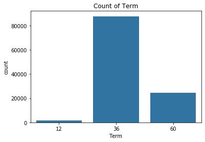

```python
b_col = sns.color_palette()[0]
sns.countplot(data = df, x = 'Term',color=b_col)
plt.title('Count of Term');
```

> From the above graph, it is clearly seen that, The maximum number of people issue loan for a period of 36 months and minimum number of people issue for a period of 12 months.

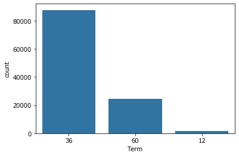

```python
b_col = sns.color_palette()[0]
cat_order = df.Term.value_counts().index
sns.countplot(data = df, x = 'Term',color=b_col,order= cat_order);
```

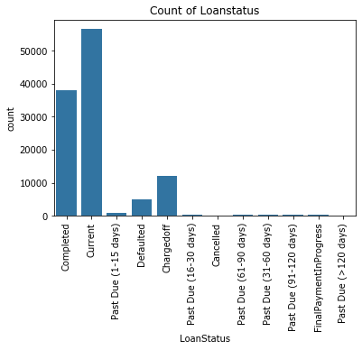

```python
b_col = sns.color_palette()[0]
sns.countplot(data = df, x = 'LoanStatus',color=b_col)
plt.xticks(rotation=90)
plt.title('Count of Loanstatus');
```

> In the graphs of Loan Status, we can find that, Current Loan status has the maximum count followed by the completed Loan status with Chargeoff, Defaulted and Past Due, following next.

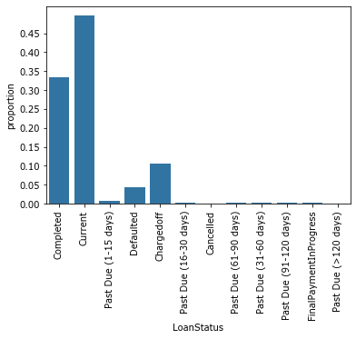

```python
n_p = df.shape[0]
max_cnt = df['LoanStatus'].value_counts().max()
max_prop = max_cnt / n_p
tick_props = np.arange(0, max_prop, 0.05)
tick_names = ['{:0.2f}'.format(v) for v in tick_props]
base_color = sns.color_palette()[0]
sns.countplot(data = df, x = 'LoanStatus', color = base_color)
plt.yticks(tick_props * n_p, tick_names)
plt.ylabel('proportion')
plt.xticks(rotation=90);
```

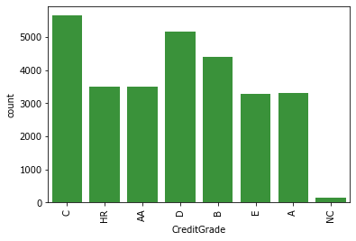

```python
b_col = sns.color_palette()[2]
sns.countplot(data = df, x = 'CreditGrade',color=b_col)
plt.xticks(rotation=90);
```

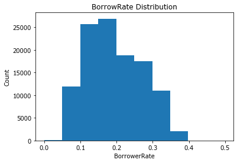

```python
bin_edges = np.arange(0, df['BorrowerRate'].max()+1, 1)
plt.hist(data = df, x = 'BorrowerRate')
plt.title('BorrowRate Distribution')
plt.xlabel('BorrowerRate')
plt.ylabel('Count');
```

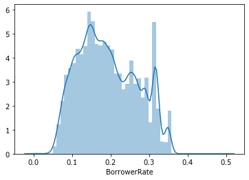

```python
sns.distplot(df['BorrowerRate']);
```

## BIVARIATE EXPLORATION

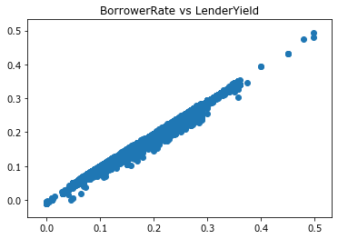

```python
plt.scatter(data = df, x = 'BorrowerRate', y = 'LenderYield')
plt.title('BorrowerRate vs LenderYield');
```

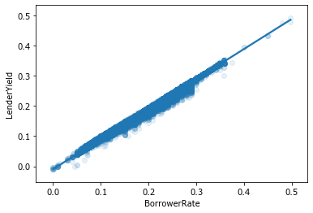

```python
sns.regplot(data = df, x = 'BorrowerRate', y = 'LenderYield', scatter_kws = {'alpha' : 1/10});
```

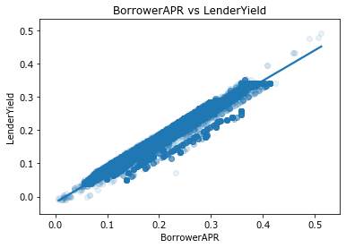

```python
sns.regplot(data = df, x = 'BorrowerAPR', y = 'LenderYield', scatter_kws = {'alpha' : 1/10})
plt.title('BorrowerAPR vs LenderYield');
```

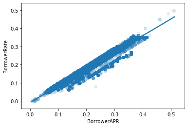

```python
sns.regplot(data = df, x = 'BorrowerAPR', y = 'BorrowerRate', scatter_kws = {'alpha' : 1/10});
```

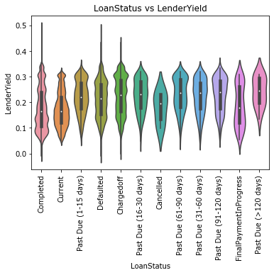

```python
sns.violinplot(data = df, x = 'LoanStatus', y = 'LenderYield')
plt.xticks(rotation=90)
plt.title('LoanStatus vs LenderYield');
```

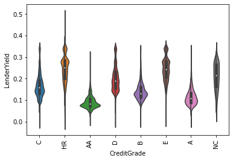

```python
sns.violinplot(data = df, x = 'CreditGrade', y = 'LenderYield')
plt.xticks(rotation=90);
```

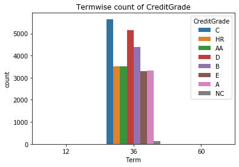

```python
sns.countplot(data = df, x = 'Term', hue = 'CreditGrade')
plt.title('Termwise count of CreditGrade');
```

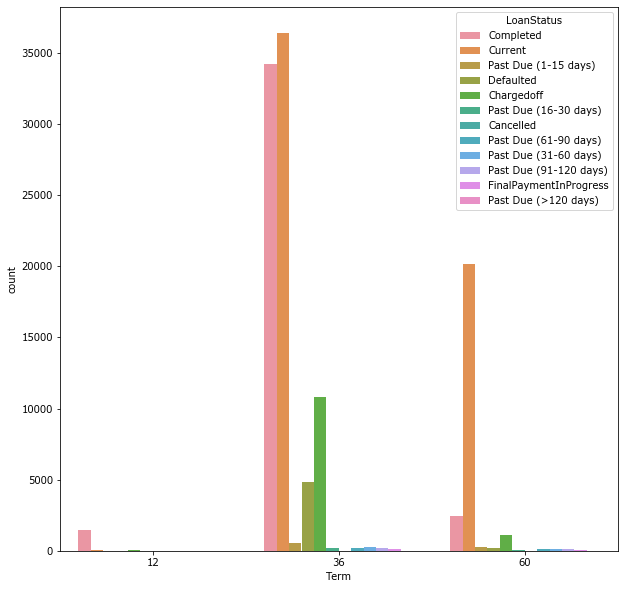

```python
plt.figure(figsize=(10,10))
sns.countplot(data = df, x = 'Term', hue = 'LoanStatus');
```

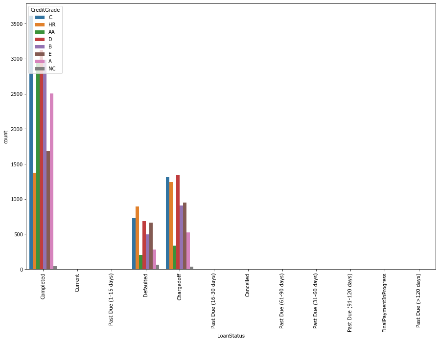

```python
plt.figure(figsize=(15,10))
sns.countplot(data = df, x = 'LoanStatus', hue = 'CreditGrade')
plt.xticks(rotation=90);
```

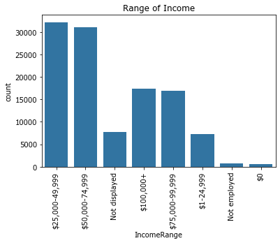

```python
b_col = sns.color_palette()[0]
sns.countplot(data = df, x = 'IncomeRange',color=b_col)
plt.title('Range of Income')
plt.xticks(rotation=90);
```

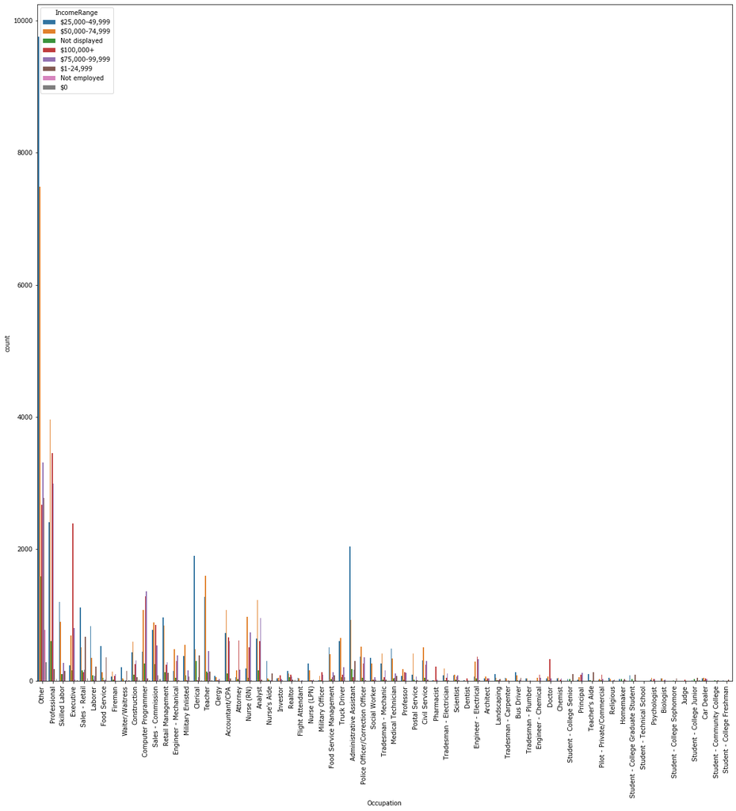

```python
plt.figure(figsize=(20,20))
sns.countplot(data = df, x = 'Occupation', hue = 'IncomeRange')
plt.xticks(rotation=90);
```

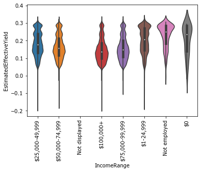

```python
sns.violinplot(data = df, x = 'IncomeRange', y = 'EstimatedEffectiveYield')
plt.xticks(rotation=90);
```

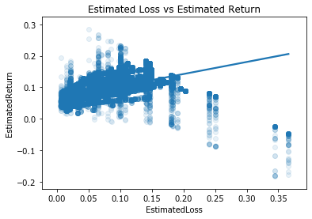

```python
sns.regplot(data = df, x = 'EstimatedLoss', y = 'EstimatedReturn', scatter_kws = {'alpha' : 1/10})
plt.title('Estimated Loss vs Estimated Return');
```

## MULTIVARIATE EXPLORATION

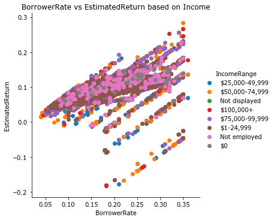

```python
g = sns.FacetGrid(data = df, hue = 'IncomeRange', height = 5)
g.map(plt.scatter,  'BorrowerRate','EstimatedReturn')
g.add_legend()
plt.title('BorrowerRate vs EstimatedReturn based on Income');
```

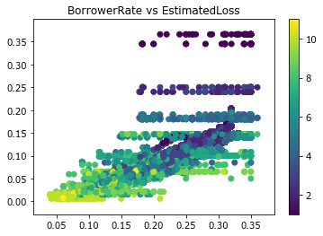

```python
plt.scatter(data = df, x = 'BorrowerRate', y = 'EstimatedLoss', c = 'ProsperScore')
plt.colorbar()
plt.title('BorrowerRate vs EstimatedLoss');
```

#### In the above multivariate exploration graphs, we can see the distribution of BorrowerRate vs. EstimatedReturn based on income.

#### We can also see the relationship between BorrowerRate and EstimatedLoss based on ProsperScore

### KEY INSIGHTS:

The loan dataset has a large number columns from which the following conclusions can be drawn:

> Most of the people issuing loans are from Grade C and Grade D category and their income range is between 25000$ - 49999$

> Greater the prosper score lesser is the risk of being at loss.